# PE_DA_540_Election_Result_Analysis_ver2

**Industry 4.0 의 중심, BigData**

Data Processing Based Python @ [FB / jskim.kr](https://www.facebook.com/jskim.kr), 김진수

## 대선 결과 분석

### 중앙선거관리위원회 선거통계시스템

> - 사이트 : http://info.nec.go.kr/
> - 19대 대통령선거 결과데이터 크롤링 및 분석
> - 결과 확인할 수 있는 페이지 : [바로가기](http://info.nec.go.kr/main/showDocument.xhtml?electionId=0000000000&topMenuId=VC&secondMenuId=VCCP09)

### STEP1 : 데이터 획득 준비 작업

```python
from images import bigpycraft_bda as bpc
from IPython.display import Image
```

```python
import platform
import numpy as np
import pandas as pd
import matplotlib.pyplot as plt
import seaborn as sns
sns.set()

from matplotlib import font_manager, rc
if platform.system() == 'Darwin':
    rc('font', family='AppleGothic')
elif platform.system() == 'Windows':
    font_name = font_manager.FontProperties(fname="C:/Windows/Fonts/malgun.ttf").get_name()
    rc('font', family=font_name)
else:
    print("It's unknown system. Hangul fonts are not supported!")

plt.rcParams["figure.figsize"] = [12,6]

%matplotlib inline
```

```python
! pip install selenium
```

```python
from selenium import webdriver
import time
import re
```

```python
driver = webdriver.Chrome('./driver/chromedriver.exe')
```

```python
# 선거결과확인페이지로 바로 이동
page_url = 'http://info.nec.go.kr/main/showDocument.xhtml?electionId=0000000000&topMenuId=VC&secondMenuId=VCCP09'
driver.get(page_url)
```

[figure not shown]

```python
capture_img = './images/electionInfo.png'
driver.save_screenshot(capture_img)
Image(capture_img)
```

#### 대통령선거 클릭 : 제19대 > 대통령선거 > 전체 를 선택후 검색 클릭

```python
# 대통령선거 클릭 : id=electionType1
driver.find_element_by_id("electionType1").click()
```

```python
# 제19대 선택
driver.find_element_by_id("electionName").send_keys("제19대")
```

```python
# 선거 : 대통령선거
driver.find_element_by_id("electionCode").send_keys("대통령선거")
```

```python
# 시도 : ▷ 전 체
driver.find_element_by_name("cityCode").send_keys("▷ 전 체")
```

```python
# 검색버튼 클릭
driver.find_element_by_css_selector('#searchBtn').click()
```

#### 결과보기 확인

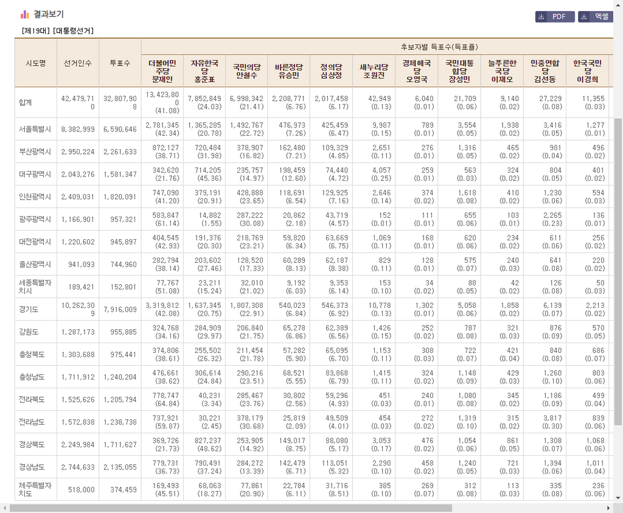

```python
capture_img = './images/electionInfo_report.png'
driver.save_screenshot(capture_img)
Image(capture_img)
```

```python
# 시도항목 리스트 정보: select box의 id 기반으로 option 리스트 가져온다.
sido_list_raw = driver.find_element_by_xpath("""//*[@id="cityCode"]""")
sido_list = sido_list_raw.find_elements_by_tag_name("option")
sido_names_values = [ option.text for option in sido_list ]
sido_names_values
```

```
['▽ 선 택',
 '▷ 전 체',
 '서울특별시',
 '부산광역시',
 '대구광역시',
 '인천광역시',
 '광주광역시',
 '대전광역시',
 '울산광역시',
 '세종특별자치시',
 '경기도',
 '강원도',
 '충청북도',
 '충청남도',
 '전라북도',
 '전라남도',
 '경상북도',
 '경상남도',
 '제주특별자치도']
```

```python
sido_names_values = sido_names_values[2:]
sido_names_values
```

```
['서울특별시',
 '부산광역시',
 '대구광역시',
 '인천광역시',
 '광주광역시',
 '대전광역시',
 '울산광역시',
 '세종특별자치시',
 '경기도',
 '강원도',
 '충청북도',
 '충청남도',
 '전라북도',
 '전라남도',
 '경상북도',
 '경상남도',
 '제주특별자치도']
```

### STEP2 : 대선 개표 결과 데이터 수집

- 결과테이블에서 득표수에 아래의 괄호()는 득표율이다.
- 괄호 (를 기준으로 왼쪽 숫자만 얻어서, 콤마(,)를 제거하고, float형으로 변경하는 함수를 get_num으로 준비

```python
from bs4 import BeautifulSoup
import re

def get_num_2(tmp):
    return float(re.split('\(', str(tmp))[0].replace(',',''))

def get_num(tmp):
    ret_val = str(tmp)
    ret_val = re.split('\(', ret_val)[0]
    ret_val = ret_val.replace(',','')
    ret_val = float(ret_val)
    return ret_val
```

#### move_sido

> - 화면이 바로 뜨지 않을 경우, wait.until 함수를 사용
> - 이 함수는 **검색**버튼이 클릭가능할 때 까지 기다리는 기능을 한다.
> - 아래 **move_sido** 함수는 광역시도 이름을 리스트에 전송하고 검색 버튼을 누르는 역할을 한다.

```python
from selenium.webdriver.common.by  import By
from selenium.webdriver.support.ui import WebDriverWait
from selenium.webdriver.support    import expected_conditions as EC

wait = WebDriverWait(driver, 10)

def move_sido(name):
    element = driver.find_element_by_id("cityCode")
    element.send_keys(name)
    make_xpath = """//*[@id="searchBtn"]"""
    wait.until(EC.element_to_be_clickable((By.XPATH,make_xpath)))
    driver.find_element_by_xpath(make_xpath).click()
```

#### append_data

> - 이 함수는 빈 내용으로 미리 준비한 DataFrame에 append 명령으로 읽은 데이터를 하나씩 추가한다.
> - 함수가 실행되면 전체 투표수, 각 후보의 득표수가 추가된다.

```python
def append_data(df, sido_name, data):
    for each in df[0].values[1:]:
        data['광역시도'].append(sido_name)
        data['시군'].append(each[0])
        data['pop' ].append(get_num(each[2]))
        data['moon'].append(get_num(each[3]))
        data['hong'].append(get_num(each[4]))
        data['ahn' ].append(get_num(each[5]))

    return data
```

- 미리 변수를 하나 만들어 둡니다.

```python
election_result_raw = {'광역시도' : [],
                       '시군' : [],
                       'pop'  : [],
                       'moon' : [],
                       'hong' : [],
                       'ahn'  : [] }
```

- 웹프로그래밍을 잘모르는 경우, 웹문서의 table로 읽는 것이 부담될 수도 있지만
- 경우에 따라 html 태그 중 table로 되어 있는 부분을 Beautiful Soup으로 읽어서 padnas의 read_html로 읽는 것이 더 편할때도 있다.

```python
# 서울특별시 결과
each_sido = sido_names_values[0]
move_sido(each_sido)
```

```python
html = driver.page_source
soup = BeautifulSoup(html, 'lxml')
table = soup.find('table')
```

```python
df = pd.read_html(str(table))
type(df), len(df)
```

```
(list, 1)
```

```python
type(df[0])
```

```
pandas.core.frame.DataFrame
```

```python
result_df = df[0]
result_df.head()
```

|  | 구시군명 더불어민주당문재인 | 선거인수 자유한국당홍준표 | 투표수 국민의당안철수 | 후보자별 득표수(득표율) 바른정당유승민 | 무효투표수 정의당심상정 | 기권수 새누리당조원진 | Unnamed: 6_level_0 경제애국당오영국 | Unnamed: 7_level_0 국민대통합당장성민 | Unnamed: 8_level_0 늘푸른한국당이재오 | Unnamed: 9_level_0 민중연합당김선동 | Unnamed: 10_level_0 한국국민당이경희 | Unnamed: 11_level_0 홍익당윤홍식 | Unnamed: 12_level_0 무소속김민찬 | Unnamed: 13_level_0 계 | Unnamed: 14_level_0 Unnamed: 14_level_1 | Unnamed: 15_level_0 Unnamed: 15_level_1 | Unnamed: 16_level_0 Unnamed: 16_level_1 | Unnamed: 17_level_0 Unnamed: 17_level_1 | Unnamed: 18_level_0 Unnamed: 18_level_1 |
| --- | --- | --- | --- | --- | --- | --- | --- | --- | --- | --- | --- | --- | --- | --- | --- | --- | --- | --- | --- |
| 0 | 합계 | 8382999 | 6590646 | 2,781,345(42.34) | 1,365,285(20.78) | 1,492,767(22.72) | 476,973(7.26) | 425,459(6.47) | 9,987(0.15) | 789(0.01) | 3,554(0.05) | 1,938(0.02) | 3,416(0.05) | 1,277(0.01) | 2,177(0.03) | 3,950(0.06) | 6568917 | 21729 | 1792353 |
| 1 | 종로구 | 133769 | 102566 | 42,512(41.59) | 22,325(21.84) | 22,313(21.83) | 7,412(7.25) | 7,113(6.95) | 228(0.22) | 5(0.00) | 78(0.07) | 31(0.03) | 63(0.06) | 26(0.02) | 47(0.04) | 49(0.04) | 102202 | 364 | 31203 |
| 2 | 중구 | 109836 | 82852 | 34,062(41.23) | 17,901(21.67) | 19,372(23.45) | 5,874(7.11) | 4,993(6.04) | 158(0.19) | 12(0.01) | 53(0.06) | 21(0.02) | 55(0.06) | 18(0.02) | 25(0.03) | 51(0.06) | 82595 | 257 | 26984 |
| 3 | 용산구 | 197962 | 148157 | 58,081(39.33) | 35,230(23.85) | 32,109(21.74) | 11,825(8.00) | 9,773(6.61) | 299(0.20) | 17(0.01) | 68(0.04) | 23(0.01) | 72(0.04) | 32(0.02) | 51(0.03) | 80(0.05) | 147660 | 497 | 49805 |
| 4 | 성동구 | 259009 | 203175 | 86,686(42.80) | 40,566(20.03) | 45,674(22.55) | 15,859(7.83) | 12,936(6.38) | 304(0.15) | 16(0.00) | 94(0.04) | 46(0.02) | 108(0.05) | 41(0.02) | 58(0.02) | 124(0.06) | 202512 | 663 | 55834 |

```python
result_df.info()
```

```
<class 'pandas.core.frame.DataFrame'>
RangeIndex: 26 entries, 0 to 25
Data columns (total 19 columns):
(구시군명, 더불어민주당문재인)                             26 non-null object
(선거인수, 자유한국당홍준표)                              26 non-null int64
(투표수, 국민의당안철수)                                26 non-null int64
(후보자별 득표수(득표율), 바른정당유승민)                      26 non-null object
(무효투표수, 정의당심상정)                               26 non-null object
(기권수, 새누리당조원진)                                26 non-null object
(Unnamed: 6_level_0, 경제애국당오영국)                26 non-null object
(Unnamed: 7_level_0, 국민대통합당장성민)               26 non-null object
(Unnamed: 8_level_0, 늘푸른한국당이재오)               26 non-null object
(Unnamed: 9_level_0, 민중연합당김선동)                26 non-null object
(Unnamed: 10_level_0, 한국국민당이경희)               26 non-null object
(Unnamed: 11_level_0, 홍익당윤홍식)                 26 non-null object
(Unnamed: 12_level_0, 무소속김민찬)                 26 non-null object
(Unnamed: 13_level_0, 계)                      26 non-null object
(Unnamed: 14_level_0, Unnamed: 14_level_1)    26 non-null object
(Unnamed: 15_level_0, Unnamed: 15_level_1)    26 non-null object
(Unnamed: 16_level_0, Unnamed: 16_level_1)    26 non-null int64
(Unnamed: 17_level_0, Unnamed: 17_level_1)    26 non-null int64
(Unnamed: 18_level_0, Unnamed: 18_level_1)    26 non-null int64
dtypes: int64(5), object(14)
memory usage: 3.9+ KB
```

```python
result_df.values[1:5]
```

```
array([['종로구', 133769, 102566, '42,512(41.59)', '22,325(21.84)',
        '22,313(21.83)', '7,412(7.25)', '7,113(6.95)', '228(0.22)',
        '5(0.00)', '78(0.07)', '31(0.03)', '63(0.06)', '26(0.02)',
        '47(0.04)', '49(0.04)', 102202, 364, 31203],
       ['중구', 109836, 82852, '34,062(41.23)', '17,901(21.67)',
        '19,372(23.45)', '5,874(7.11)', '4,993(6.04)', '158(0.19)',
        '12(0.01)', '53(0.06)', '21(0.02)', '55(0.06)', '18(0.02)',
        '25(0.03)', '51(0.06)', 82595, 257, 26984],
       ['용산구', 197962, 148157, '58,081(39.33)', '35,230(23.85)',
        '32,109(21.74)', '11,825(8.00)', '9,773(6.61)', '299(0.20)',
        '17(0.01)', '68(0.04)', '23(0.01)', '72(0.04)', '32(0.02)',
        '51(0.03)', '80(0.05)', 147660, 497, 49805],
       ['성동구', 259009, 203175, '86,686(42.80)', '40,566(20.03)',
        '45,674(22.55)', '15,859(7.83)', '12,936(6.38)', '304(0.15)',
        '16(0.00)', '94(0.04)', '46(0.02)', '108(0.05)', '41(0.02)',
        '58(0.02)', '124(0.06)', 202512, 663, 55834]], dtype=object)
```

```python
print(" df : {}, \n each_sido : {}, \n election_result_raw : {}".format(
    df, each_sido, election_result_raw
))
```

```
 df : [        구시군명     선거인수      투표수     후보자별 득표수(득표율)             무효투표수  \
   더불어민주당문재인 자유한국당홍준표  국민의당안철수           바른정당유승민            정의당심상정
0         합계  8382999  6590646  2,781,345(42.34)  1,365,285(20.78)
1        종로구   133769   102566     42,512(41.59)     22,325(21.84)
2         중구   109836    82852     34,062(41.23)     17,901(21.67)
3        용산구   197962   148157     58,081(39.33)     35,230(23.85)
4        성동구   259009   203175     86,686(42.80)     40,566(20.03)
5        광진구   305172   240030    105,512(44.10)     46,368(19.38)
6       동대문구   304972   236092     98,958(42.06)     51,631(21.94)
7        중랑구   351986   265706    111,450(42.09)     56,545(21.35)
8        성북구   378024   295866    129,263(43.82)     57,584(19.52)
9        강북구   281434   210614     89,645(42.70)     42,268(20.13)
10       도봉구   293679   229233     94,898(41.55)     47,461(20.78)
11       노원구   464422   374213    158,167(42.41)     67,590(18.12)
12       은평구   413086   317275    140,180(44.34)     60,109(19.01)
```

[output cut: 160 more lines]

```python
type(df), each_sido, election_result_raw
```

```
(list,
 '서울특별시',
 {'ahn': [], 'hong': [], 'moon': [], 'pop': [], '광역시도': [], '시군': []})
```

```python
sido_data = append_data(df, each_sido, election_result_raw)
```

```python
sido_data
```

```
{'ahn': [22313.0,
  19372.0,
  32109.0,
  45674.0,
  52824.0,
  53359.0,
  62778.0,
  66518.0,
  51669.0,
  55600.0,
  96325.0,
  72582.0,
  46237.0,
  52545.0,
  71816.0,
  88128.0,
  61734.0,
  36695.0,
  53994.0,
  60305.0,
  79495.0,
  63977.0,
  80201.0,
  99018.0,
  67499.0],
 'hong': [22325.0,
  17901.0,
  35230.0,
  40566.0,
  46368.0,
  51631.0,
  56545.0,
  57584.0,
  42268.0,
  47461.0,
  67590.0,
  60109.0,
  40513.0,
  46547.0,
  60814.0,
```

[output cut: 95 more lines]

```
  '노원구',
  '은평구',
  '서대문구',
  '마포구',
  '양천구',
  '강서구',
  '구로구',
  '금천구',
  '영등포구',
  '동작구',
  '관악구',
  '서초구',
  '강남구',
  '송파구',
  '강동구']}
```

```python
election_result_raw = {'광역시도' : [],
                       '시군' : [],
                       'pop'  : [],
                       'moon' : [],
                       'hong' : [],
                       'ahn'  : [] }
```

```python
for each_sido in sido_names_values:
    move_sido(each_sido)

    html = driver.page_source
    soup = BeautifulSoup(html, 'lxml')
    table = soup.find('table')

    df = pd.read_html(str(table))

    print(" df : {}, \n each_sido : {}, \n election_result_raw : {}".format(
        df, each_sido, election_result_raw
    ))
    append_data(df, each_sido, election_result_raw)
```

[output not shown]

[output cut: 1860 more lines]

```python
election_result = pd.DataFrame(election_result_raw,
                               columns=['광역시도', '시군', 'pop', 'moon','hong','ahn'])
election_result
```

|  | 광역시도 | 시군 | pop | moon | hong | ahn |
| --- | --- | --- | --- | --- | --- | --- |
| 0 | 서울특별시 | 종로구 | 102566.0 | 42512.0 | 22325.0 | 22313.0 |
| 1 | 서울특별시 | 중구 | 82852.0 | 34062.0 | 17901.0 | 19372.0 |
| 2 | 서울특별시 | 용산구 | 148157.0 | 58081.0 | 35230.0 | 32109.0 |
| 3 | 서울특별시 | 성동구 | 203175.0 | 86686.0 | 40566.0 | 45674.0 |
| 4 | 서울특별시 | 광진구 | 240030.0 | 105512.0 | 46368.0 | 52824.0 |
| 5 | 서울특별시 | 동대문구 | 236092.0 | 98958.0 | 51631.0 | 53359.0 |
| 6 | 서울특별시 | 중랑구 | 265706.0 | 111450.0 | 56545.0 | 62778.0 |
| 7 | 서울특별시 | 성북구 | 295866.0 | 129263.0 | 57584.0 | 66518.0 |
| 8 | 서울특별시 | 강북구 | 210614.0 | 89645.0 | 42268.0 | 51669.0 |
| 9 | 서울특별시 | 도봉구 | 229233.0 | 94898.0 | 47461.0 | 55600.0 |
| 10 | 서울특별시 | 노원구 | 374213.0 | 158167.0 | 67590.0 | 96325.0 |
| 11 | 서울특별시 | 은평구 | 317275.0 | 140180.0 | 60109.0 | 72582.0 |
| 12 | 서울특별시 | 서대문구 | 212076.0 | 93768.0 | 40513.0 | 46237.0 |
| 13 | 서울특별시 | 마포구 | 256992.0 | 117336.0 | 46547.0 | 52545.0 |
| 14 | 서울특별시 | 양천구 | 310886.0 | 133853.0 | 60814.0 | 71816.0 |
| 15 | 서울특별시 | 강서구 | 397108.0 | 175882.0 | 76601.0 | 88128.0 |
| 16 | 서울특별시 | 구로구 | 278805.0 | 121077.0 | 59194.0 | 61734.0 |
| 17 | 서울특별시 | 금천구 | 155010.0 | 67423.0 | 31106.0 | 36695.0 |
| 18 | 서울특별시 | 영등포구 | 248833.0 | 105834.0 | 53615.0 | 53994.0 |
| 19 | 서울특별시 | 동작구 | 276685.0 | 121722.0 | 54431.0 | 60305.0 |
| 20 | 서울특별시 | 관악구 | 351240.0 | 159854.0 | 59914.0 | 79495.0 |
| 21 | 서울특별시 | 서초구 | 292916.0 | 106416.0 | 74891.0 | 63977.0 |
| 22 | 서울특별시 | 강남구 | 365642.0 | 128927.0 | 97639.0 | 80201.0 |
| 23 | 서울특별시 | 송파구 | 441198.0 | 177328.0 | 98549.0 | 99018.0 |
| 24 | 서울특별시 | 강동구 | 297476.0 | 122511.0 | 65893.0 | 67499.0 |
| 25 | 부산광역시 | 중구 | 28604.0 | 9918.0 | 10684.0 | 4675.0 |
| 26 | 부산광역시 | 서구 | 71446.0 | 24522.0 | 26360.0 | 11868.0 |
| 27 | 부산광역시 | 동구 | 58304.0 | 19606.0 | 22188.0 | 9815.0 |
| 28 | 부산광역시 | 영도구 | 78013.0 | 30094.0 | 25345.0 | 13082.0 |
| 29 | 부산광역시 | 부산진구 | 246124.0 | 95042.0 | 79545.0 | 40636.0 |
| ... | ... | ... | ... | ... | ... | ... |
| 220 | 경상북도 | 의성군 | 37855.0 | 5365.0 | 23790.0 | 4767.0 |
| 221 | 경상북도 | 청송군 | 18418.0 | 3218.0 | 10669.0 | 2387.0 |
| 222 | 경상북도 | 영양군 | 12048.0 | 2281.0 | 6554.0 | 1701.0 |
| 223 | 경상북도 | 영덕군 | 26125.0 | 3786.0 | 16314.0 | 3231.0 |
| 224 | 경상북도 | 봉화군 | 22947.0 | 4209.0 | 12536.0 | 3370.0 |
| 225 | 경상북도 | 울진군 | 32568.0 | 6972.0 | 16867.0 | 4476.0 |
| 226 | 경상남도 | 창원시의창구 | 164047.0 | 60757.0 | 56887.0 | 22830.0 |
| 227 | 경상남도 | 창원시성산구 | 153327.0 | 63717.0 | 42052.0 | 22923.0 |
| 228 | 경상남도 | 창원시마산합포구 | 119281.0 | 35592.0 | 54488.0 | 14686.0 |
| 229 | 경상남도 | 창원시마산회원구 | 136757.0 | 45014.0 | 56340.0 | 17744.0 |
| 230 | 경상남도 | 창원시진해구 | 114779.0 | 41249.0 | 40049.0 | 17435.0 |
| 231 | 경상남도 | 진주시 | 222813.0 | 73929.0 | 93751.0 | 26687.0 |
| 232 | 경상남도 | 통영시 | 82855.0 | 25477.0 | 36128.0 | 10738.0 |
| 233 | 경상남도 | 고성군 | 34603.0 | 9848.0 | 16797.0 | 4104.0 |
| 234 | 경상남도 | 사천시 | 71555.0 | 22370.0 | 32475.0 | 8350.0 |
| 235 | 경상남도 | 김해시 | 318253.0 | 147972.0 | 82880.0 | 45126.0 |
| 236 | 경상남도 | 밀양시 | 70687.0 | 20842.0 | 32394.0 | 9073.0 |
| 237 | 경상남도 | 거제시 | 150230.0 | 68291.0 | 38775.0 | 20359.0 |
| 238 | 경상남도 | 의령군 | 19258.0 | 5115.0 | 10134.0 | 1984.0 |
| 239 | 경상남도 | 함안군 | 43866.0 | 13597.0 | 19809.0 | 5399.0 |
| 240 | 경상남도 | 창녕군 | 42878.0 | 10310.0 | 24464.0 | 3877.0 |
| 241 | 경상남도 | 양산시 | 199835.0 | 83412.0 | 58811.0 | 30945.0 |
| 242 | 경상남도 | 하동군 | 34324.0 | 11211.0 | 14864.0 | 4150.0 |
| 243 | 경상남도 | 남해군 | 30208.0 | 8680.0 | 14166.0 | 3906.0 |
| 244 | 경상남도 | 함양군 | 26640.0 | 7388.0 | 13008.0 | 3203.0 |
| 245 | 경상남도 | 산청군 | 24513.0 | 6561.0 | 12544.0 | 2753.0 |
| 246 | 경상남도 | 거창군 | 41325.0 | 11256.0 | 19976.0 | 4923.0 |
| 247 | 경상남도 | 합천군 | 33021.0 | 7143.0 | 19699.0 | 3077.0 |
| 248 | 제주특별자치도 | 제주시 | 273163.0 | 125717.0 | 48027.0 | 55971.0 |
| 249 | 제주특별자치도 | 서귀포시 | 101296.0 | 43776.0 | 20036.0 | 21890.0 |

250 rows × 6 columns

```python
election_result.to_csv('data/election_result.csv', encoding='utf-8', sep=',')
```

```python
driver.close()
```

### STEP3 : 각 후보의 득표율과 지역 ID 정리

[figure not shown]

```python
# drawKorea('ahn_vs_hong', final_elect_data, 'RdBu')
```